# Chapter 8 - Feature Engineering with recipes

```r
here::i_am(fs::path("tidy-modeling-with-r", "chapter-08.qmd"))
```

```
here() starts at /home/alex/r-projects/brush-up
```

```r
library(here)
source(here("tidy-modeling-with-r", "setup.R"))
```

feature engineering - authors give an example say you have two predictors that are better expressed as a ratio of these two. this is feature engineering.

authors provide a few examples of preprocessing for better feature engineering:

- Correlation between predictors can be reduced via feature extraction or the removal of some predictors.
- When some predictors have missing values, they can be imputed using a sub-model.
- Models that use variance-type measures may benefit from coercing the distribution of some skewed predictors to be symmetric by estimating a transformation.

they note that different models have different preprocessing requirements and then some like tree-based models need almost nothing in terms of preproc.

they list an appendix, appendix a in the back of the book

## a simple `recipe()` for the ames housing data

authors state that we’ll be looking at the following predictors:

- The neighborhood (qualitative, with 29 neighborhoods in the training set)

-The gross above-grade living area (continuous, named Gr_Liv_Area)

- The year built (Year_Built)
- The type of building (Bldg_Type with values OneFam (n=1,936), TwoFmCon (n=50), Duplex (n=88), Twnhs (n=77), and TwnhsE (n=191))

They point out that traditionally we might’ve used an r formula like this:

```r
lm(
  Sale_Price ~ Neighborhood + log10(Gr_Liv_Area) + Year_Built + Bldg_Type,
  data = ames
)
```

```
Call:
lm(formula = Sale_Price ~ Neighborhood + log10(Gr_Liv_Area) +
    Year_Built + Bldg_Type, data = ames)

Coefficients:
                                        (Intercept)
                                         -0.8551717
                          NeighborhoodCollege_Creek
                                          0.0135485
                               NeighborhoodOld_Town
                                         -0.0289607
                                NeighborhoodEdwards
                                         -0.0493174
                               NeighborhoodSomerset
                                          0.0499653
                     NeighborhoodNorthridge_Heights
                                          0.1335758
                                NeighborhoodGilbert
                                         -0.0337334
                                 NeighborhoodSawyer
                                         -0.0042779
                         NeighborhoodNorthwest_Ames
                                          0.0004589
                            NeighborhoodSawyer_West
                                         -0.0174582
                               NeighborhoodMitchell
                                          0.0004695
                              NeighborhoodBrookside
                                         -0.0110205
                               NeighborhoodCrawford
                                          0.0914254
                 NeighborhoodIowa_DOT_and_Rail_Road
                                         -0.0839821
                             NeighborhoodTimberland
                                          0.0604062
                             NeighborhoodNorthridge
                                          0.0845868
                            NeighborhoodStone_Brook
                                          0.1459657
NeighborhoodSouth_and_West_of_Iowa_State_University
```

[output cut: 18 more lines]

```
                                          0.2229230
                               NeighborhoodLandmark
                                         -0.0119925
                                 log10(Gr_Liv_Area)
                                          0.6343996
                                         Year_Built
                                          0.0020678
                                  Bldg_TypeTwoFmCon
                                         -0.0312306
                                    Bldg_TypeDuplex
                                         -0.1038443
                                     Bldg_TypeTwnhs
                                         -0.0968859
                                    Bldg_TypeTwnhsE
                                         -0.0414929
```

the authors then go through disecting what is happening with the traditional formula. Some of it is obvious, some of it is not, like the invisible non-numeric to numeric conversions.

whereas `recipes()` uses `step_*` family of functions.

```r
simple_ames <-
  recipe(
    Sale_Price ~ Neighborhood + Gr_Liv_Area + Year_Built + Bldg_Type,
    data = ames_train
  ) |>
  step_log(Gr_Liv_Area, base = 10) |>
  step_dummy(all_nominal_predictors())
simple_ames
```

```
── Recipe ──────────────────────────────────────────────────────────────────────
```

```
── Inputs
```

```
Number of variables by role
```

```
outcome:   1
predictor: 4
```

```
── Operations
```

```
• Log transformation on: Gr_Liv_Area
```

```
• Dummy variables from: all_nominal_predictors()
```

wow thats incredible some advantages: - standardized and recyclable - more preproc choices vs formula + package alone - syntax can be compact with the selector helpers - everything in one object

lets try using a recipe with our old wflow

```r
lm_wflow |>
  add_recipe(simple_ames)
```

oh no doesn’t work

authors explain that you can only have one preproc method at a time and we did that one manually.

lets fix it

```r
lm_wflow <-
  lm_wflow |>
  remove_variables() |>
  remove_recipe() |>
  add_recipe(simple_ames)
lm_wflow
```

```
══ Workflow ════════════════════════════════════════════════════════════════════
Preprocessor: Recipe
Model: linear_reg()

── Preprocessor ────────────────────────────────────────────────────────────────
2 Recipe Steps

• step_log()
• step_dummy()

── Model ───────────────────────────────────────────────────────────────────────
Linear Regression Model Specification (regression)

Computational engine: lm
```

neat

```r
lm_fit <- fit(lm_wflow, ames_train)
```

the authors state that now, the `predict()` method will apply the exact same preprocessing that was used on the training set to the new data before passing them along to the model’s prediction method. that awesome, so it’s deduplicating code. t

my thoughts - he invisibility of it, is a little tough to wrap my head around BUT I think the enforced standard and single point of entry forcing you to use good practice far outweighs that.

lets predict

```r
predict(lm_fit, ames_test |> slice(1:3)) |> suppressWarnings()
```

```
# A tibble: 3 × 1
  .pred
  <dbl>
1  5.08
2  5.32
3  5.28
```

extract_ funs can give us the bits and pieces

```r
lm_fit |>
  extract_recipe(estimated = TRUE)
```

```
── Recipe ──────────────────────────────────────────────────────────────────────
```

```
── Inputs
```

```
Number of variables by role
```

```
outcome:   1
predictor: 4
```

```
── Training information
```

```
Training data contained 2342 data points and no incomplete rows.
```

```
── Operations
```

```
• Log transformation on: Gr_Liv_Area | Trained
```

```
• Dummy variables from: Neighborhood Bldg_Type | Trained
```

tidy up the model fit

```r
lm_fit |>
  extract_fit_parsnip() |>
  tidy() |>
  slice(1:5)
```

```
# A tibble: 5 × 5
  term                       estimate std.error statistic   p.value
  <chr>                         <dbl>     <dbl>     <dbl>     <dbl>
1 (Intercept)                -0.669    0.231        -2.90 3.80e-  3
2 Gr_Liv_Area                 0.620    0.0143       43.2  2.63e-299
3 Year_Built                  0.00200  0.000117     17.1  6.16e- 62
4 Neighborhood_College_Creek  0.0178   0.00819       2.17 3.02e-  2
5 Neighborhood_Old_Town      -0.0330   0.00838      -3.93 8.66e-  5
```

recipes keep to only the training data - preventing leakage

## example of recipe steps

the authors give an example about common feature engineering tasks. so one example is basically factor lumping. so with the neighborhoods var, you have 2 levels that contain most of the data, and then a big middle, but there are some small `hoods with only 1 house etc…. those can be lumped into “other” like the factor rollupstuff from forcats.

```r
simple_ames <-
  recipe(
    Sale_Price ~ Neighborhood + Gr_Liv_Area + Year_Built + Bldg_Type,
    data = ames_train
  ) |>
  step_log(Gr_Liv_Area, base = 10) |>
  step_other(Neighborhood, threshold = 0.01) |>
  step_dummy(all_nominal_predictors())

# authors note that many but not all model calcs require
# predictors to be numbers.
# exception to this are -  treeobased, rulebased and naive bayes
# models
```

authors go over the dummy columns for bldg_type var and the basic conventions, and how they are made a certain way in part because of the underlying matrix algebra.

authors then go on to explain different types of preproc encoding and how different steps do different things and models have different needs. there are more args inside of the step_* funcs for more granularity. and often there is cleaner output like with var names when dummies are created vs base r dummies.

### interaction terms

interaction effects involve two or more predictors. such an effect occurs when one predicotr has an effect on the outcome that is contingent on one of more other predictors.

lets look living area vs bldg type and the resulting sale price

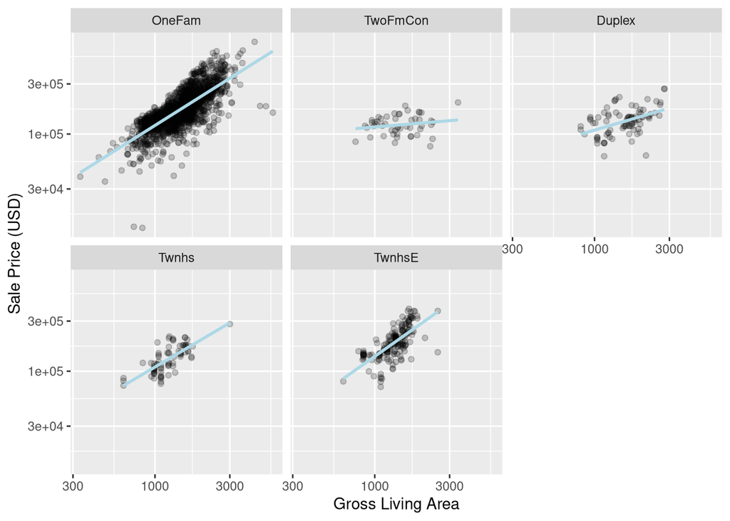

```r
ggplot(ames_train, aes(x = Gr_Liv_Area, y = 10^Sale_Price)) +
  geom_point(alpha = .2) +
  facet_wrap(~Bldg_Type) +
  geom_smooth(method = lm, formula = y ~ x, se = FALSE, color = "lightblue") +
  scale_x_log10() +
  scale_y_log10() +
  labs(x = "Gross Living Area", y = "Sale Price (USD)")
```

how are interactions specified in a recipe?

in base r you can use : - but more commonly I’ve used * so it might look like the following:

```r
Sale_Price ~
  Neighborhood + log10(Gr_Liv_Area) + Bldg_Type + log10(Gr_Liv_Area):Bldg_Type
```

```
Sale_Price ~ Neighborhood + log10(Gr_Liv_Area) + Bldg_Type +
    log10(Gr_Liv_Area):Bldg_Type
```

```r
# or
Sale_Price ~ Neighborhood + log10(Gr_Liv_Area) * Bldg_Type
```

```
Sale_Price ~ Neighborhood + log10(Gr_Liv_Area) * Bldg_Type
```

recipes on the other hand are more explicit and sequentianl and offer up more control.

let’s write one out using a recipe:

```r
simples_ames <-
  recipe(
    Sale_Price ~ Neighborhood + Gr_Liv_Area + Year_Built + Bldg_Type,
    data = ames_train
  ) |>
  step_log(Gr_Liv_Area, base = 10) |>
  step_other(Neighborhood, threshold = 0.01) |>
  step_dummy(all_nominal_predictors()) |>
  # this stuff we did before ^ now for the new stuff
  step_interact(~ Gr_Liv_Area:starts_with("Bldg_Type_"))
```

Okay so lets break this down -

1. additional interactions can be added in that single step by just adding a + between the distinct interacs so like `step_interact(~ x1:x2 + x3:x4)`
2. so why the `starts_with()` - thats because bldg_type was converted to dummyvars and the original data is striped out and replaced with the 4 binary columns for the 5 options (columns is number of groups minus 1 (n-1))
3. if we had not made dummies it would be inappropriate to include a factor column in this recipe

some of the what is being said here is confusing to me. they say a factor is inappropriate and that it’s telling base r to make dummies and then form interactions and we’d get warnings. however I tried this with the factor and there was no warning, also…. isn’t that what we did? we made dummies and then did the interaction?? perhaps this is a typo? maybe I can reach out….

anywho

the interaction vars that get made end up having nice names like `Gr_Liv_Area_x_Bldg_Type_Duplex` instead of `Gr_Liv_Area:Bldg_TypeDuplex` which is not a valid column name for dataframes.

author then goes on to state that order matters - notice the log transform at the beginning of the recipe, all further interactions will also use the log scale WHICH also leads me to believe there is a typo/ logic mismatch in this chapter section (end of 8.4.2)

### Spline functions

author states that when a predictor has a nonlinear relationship with the outcome, some models can adaptively predict this relationship during training.

simple is usually better, so folks may try to keep to a simple model, like a linear fit and add nonlinear feature for predictors that need them like (long and lat).

a common way of doing this is with the spline function.

> splines replace existing numeric predictors with a set of columns that allow a model to emulate a flexible, nonlinear relationship.

as more spline terms are added: + capacity to represent relationship - generalizability (i.e. + overfitting)

think default `geom_smooth()` in ggplot2

the authors used a couple of other packages and plotted with ggplot to tests out a different number of splines with 5 and 20 looking the best compared to 2 and 100.

to recreate these splines there is `step_ns()`

```r
recipe(
  Sale_Price ~ Neighborhood + Gr_Liv_Area + Year_Built + Bldg_Type + Latitude,
  data = ames_train
) |>
  step_log(Gr_Liv_Area, base = 10) |>
  step_other(Neighborhood, threshold = 0.01) |>
  step_dummy(all_nominal_predictors()) |>
  step_interact(~ Gr_Liv_Area:starts_with("Bldg_Type_")) |>
  # new step below
  step_ns(latitude, deg_free = 20)
```

```
── Recipe ──────────────────────────────────────────────────────────────────────
```

```
── Inputs
```

```
Number of variables by role
```

```
outcome:   1
predictor: 5
```

```
── Operations
```

```
• Log transformation on: Gr_Liv_Area
```

```
• Collapsing factor levels for: Neighborhood
```

```
• Dummy variables from: all_nominal_predictors()
```

```
• Interactions with: Gr_Liv_Area:starts_with("Bldg_Type_")
```

```
• Natural splines on: latitude
```

the author states that the user would need to determine if *both* the neighborhood and latitude should be in the model since they both represent the same underlying data in different ways.

### Feature Extraction

another common method for representing multiple features at once is called *feature extraction*.

principal component analysis (PCA) is one such method - hey I’ve used that!

PCA tries to extract as much of the original info in the predictor set as possible while using a smaller number of features.

PCA is a linear axtraction method - each new feature is a linear combo of the original preditors.

a nice plus with PCA is that: each new feature - called a principal component or PCA score is uncorrelated with one another. PCA can be very effective at reducing the correlation between predictors. however pca is *only* aware of predictors. the new features might not be associated with the outcome.

so with ames: several vars more or less measure the same thing. the space of the house (vars for basement size, 1st floor size, gross liv area…) users should think - hey maybe PCA would be an option to represent these *possibly* redundant variables as a smaller feautre set. also, look, most of these ars have SF (sqaure feet) in the name, minus one.

so folks could use

```r
step_pca(matches("(SF$)|(Gr_Liv)"))
```

FYI - in this case all measurements are sqft -which is good. for cpa to be effective they should all be the same measurement. however these can be normalized with `step_normalize()` before the pca (can we also just convert to same measurement? should we convert and then normalize?)

there are other extraction methods mentioned but not explained:

1. independant component analysis (ICA)
2. non-negative matric factorization (NNMF)
3. multidimensional scaling (MDS)
4. uniform manifold approximation and projection (UMAP)
5. and others….

### row sampling steps

for class imbalances (remember when this ws mentioned way back)

dont usually improve overall performance, but generate better “behaved” distributions.

there is: - Downsampling - keeps minority class and randomly samples the majority class - Upsampling - replicate samples of minority class to balance the overall out. some do this by creating new sample that resemble minority class, and others just add the minority samples up over and over. - Hybrid - a combo of the above

there is a `themis` package that has recipe steps to do the following:

```r
step_downsample(outcome_column_name)
```

there are other row-based step funs as well. the above and all the others pretyy much all have a parameter `skip = TRUE` which means only the training set is affected by these techniques. which is how this should be done for pretty much every usecase.

### General transformations

for straightforward transformations like dividing to compute a ratio. there is a dplyr-like fun `step_mutate()`. e.g. with ames - `step_mutate(new_pred = Bedroom_AbvGr / Full_Bath)` or something like that.

authors state- this step is flexible so be extra careful to avoid data leakage! watch out for this:

x = w > mean(w) <- so that would happen with our testing but then when applied to new data or testing, this transform would use the mean of the new data, not the mean of W from training.

^ you always want to carry the mean from training forward.

### natural language processing

there is a `textrecipes` package that can apply nlp methods to data. input is usually a string column. and dif steps can tokenize the data, filter and create new features. author does not provide examples

## skipping steps for new data

SOO if you recall we log transformed sales price already

why not use step_log(Sale_Price, base =10) in our recipe?

this can cause failures when applied to properties with unknown price. remember we are *trying* to predict price. we probably wont even have a sales price column on the test data or real life data. in fact many tidymodels package isolate the data so that there *will* be no outcome columns available at prediction time.

> for simple transformations on outcome vars it is **strongly** adivsed to **conduct those outside of the recipe**

so consider that subsampling might want to downsample all the data but the subsampling should not be applied to the predication data.

## tidy a recipe

there is also a tidy for a recipe.

```r
ames_rec <-
  recipe(
    Sale_Price ~
      Neighborhood +
        Gr_Liv_Area +
        Year_Built +
        Bldg_Type +
        Latitude +
        Longitude,
    data = ames_train
  ) |>
  step_log(Gr_Liv_Area, base = 10) |>
  step_other(Neighborhood, threshold = 0.01) |>
  step_dummy(all_nominal_predictors()) |>
  step_interact(~ Gr_Liv_Area:starts_with("Bldg_Type_")) |>
  step_ns(Latitude, Longitude, deg_free = 20)


ames_rec
```

```
── Recipe ──────────────────────────────────────────────────────────────────────
```

```
── Inputs
```

```
Number of variables by role
```

```
outcome:   1
predictor: 6
```

```
── Operations
```

```
• Log transformation on: Gr_Liv_Area
```

```
• Collapsing factor levels for: Neighborhood
```

```
• Dummy variables from: all_nominal_predictors()
```

```
• Interactions with: Gr_Liv_Area:starts_with("Bldg_Type_")
```

```
• Natural splines on: Latitude Longitude
```

```r
tidy(ames_rec)
```

```
# A tibble: 5 × 6
  number operation type     trained skip  id
   <int> <chr>     <chr>    <lgl>   <lgl> <chr>
1      1 step      log      FALSE   FALSE log_3tGFw
2      2 step      other    FALSE   FALSE other_PW6gd
3      3 step      dummy    FALSE   FALSE dummy_for8K
4      4 step      interact FALSE   FALSE interact_zm0tx
5      5 step      ns       FALSE   FALSE ns_9aI3F
```

this gives a nice play by play - notice the ids. we can supply our own.

```r
ames_rec <-
  recipe(
    Sale_Price ~
      Neighborhood +
        Gr_Liv_Area +
        Year_Built +
        Bldg_Type +
        Latitude +
        Longitude,
    data = ames_train
  ) |>
  step_log(Gr_Liv_Area, base = 10) |>
  step_other(Neighborhood, threshold = 0.01, id = "my_id") |> # id
  step_dummy(all_nominal_predictors()) |>
  step_interact(~ Gr_Liv_Area:starts_with("Bldg_Type_")) |>
  step_ns(Latitude, Longitude, deg_free = 20)
```

and refit

```r
lm_wflow <-
  workflow() |>
  add_model(lm_model) |>
  add_recipe(ames_rec)

lm_fit <- fit(lm_wflow, ames_train)

estimated_recipe <-
  lm_fit |>
  extract_recipe(estimated = TRUE)
```

you can recall that step and look at the details using the id

```r
estimated_recipe
```

```
── Recipe ──────────────────────────────────────────────────────────────────────
```

```
── Inputs
```

```
Number of variables by role
```

```
outcome:   1
predictor: 6
```

```
── Training information
```

```
Training data contained 2342 data points and no incomplete rows.
```

```
── Operations
```

```
• Log transformation on: Gr_Liv_Area | Trained
```

```
• Collapsing factor levels for: Neighborhood | Trained
```

```
• Dummy variables from: Neighborhood Bldg_Type | Trained
```

```
• Interactions with: Gr_Liv_Area:(Bldg_Type_TwoFmCon + Bldg_Type_Duplex +
  Bldg_Type_Twnhs + Bldg_Type_TwnhsE) | Trained
```

```
• Natural splines on: Latitude Longitude | Trained
```

```r
tidy(estimated_recipe)
```

```
# A tibble: 5 × 6
  number operation type     trained skip  id
   <int> <chr>     <chr>    <lgl>   <lgl> <chr>
1      1 step      log      TRUE    FALSE log_tADQ0
2      2 step      other    TRUE    FALSE my_id
3      3 step      dummy    TRUE    FALSE dummy_tbdpq
4      4 step      interact TRUE    FALSE interact_tBujn
5      5 step      ns       TRUE    FALSE ns_xPHbu
```

```r
identical(
  tidy(estimated_recipe, id = "my_id"), # or
  tidy(estimated_recipe, number = 2)
)
```

```
[1] TRUE
```

```r
tidy(estimated_recipe, number = 2)
```

```
# A tibble: 22 × 3
   terms        retained           id
   <chr>        <chr>              <chr>
 1 Neighborhood North_Ames         my_id
 2 Neighborhood College_Creek      my_id
 3 Neighborhood Old_Town           my_id
 4 Neighborhood Edwards            my_id
 5 Neighborhood Somerset           my_id
 6 Neighborhood Northridge_Heights my_id
 7 Neighborhood Gilbert            my_id
 8 Neighborhood Sawyer             my_id
 9 Neighborhood Northwest_Ames     my_id
10 Neighborhood Sawyer_West        my_id
# ℹ 12 more rows
```

lets try another

```r
tidy(estimated_recipe, number = 3) # the step with the dummies
```

```
# A tibble: 26 × 3
   terms        columns            id
   <chr>        <chr>              <chr>
 1 Neighborhood College_Creek      dummy_tbdpq
 2 Neighborhood Old_Town           dummy_tbdpq
 3 Neighborhood Edwards            dummy_tbdpq
 4 Neighborhood Somerset           dummy_tbdpq
 5 Neighborhood Northridge_Heights dummy_tbdpq
 6 Neighborhood Gilbert            dummy_tbdpq
 7 Neighborhood Sawyer             dummy_tbdpq
 8 Neighborhood Northwest_Ames     dummy_tbdpq
 9 Neighborhood Sawyer_West        dummy_tbdpq
10 Neighborhood Mitchell           dummy_tbdpq
# ℹ 16 more rows
```

## column roles

recipes assing either a predictor or outcome role to each column. and there are others. you can add, remove or update with `*_role()` methods.

these roles allow columns to be kept even with the data in case they’re important and/or problematic. so they can be assessed easily.

e.g.

```r
ames_rec |> update_role(address, new_role = "street address")
```

roles are helpful with subsampling.